# Prioritizing Pacific salmon DUs for COSEWIC assessment

07 April, 2026

# 1 About

This document summarizes estimates of change in mature individuals over time for Pacific salmon Designatable Units (DUs) and associated probable COSEWIC status designations. These estimates can then be used to help COSEWIC’s Marine Fishes sub-committee identify high priority DUs for formally assessment. See these links for information on [Data sources](https://github.com/Pacific-salmon-assess/COSEWIC-prioritize#data-sources), the [data](https://github.com/hertzPSF/COSEWIC-compilation/tree/main/Output) itself, and [code](https://github.com/Pacific-salmon-assess/COSEWIC-prioritize) to reproduce this document. These materials are solely intended to support the Marine Fishes sub-committee of COSEWIC, and may not be appropriate for other applications. Much of the data that this repository leverages were compiled by Eric Hertz and colleagues at the Pacific Salmon Foundation and documented in this [GitHub repository](https://github.com/hertzPSF/COSEWIC-compilation).

# 2 Prioritization decision nodes

Some general questions to consider in the prioritization process.

1. **Have DUs been formally defined by COSEWIC?** Chinook, sockeye, and coho salmon DUs have been defined (reports available [here](https://www.cosewic.ca/index.php/en-ca/reports/special-reports.html)), formal pink and chum DU identification is in progress. If **yes** then proceed.
2. **Is information on mature individuals over time available at the DU scale?** If **yes** then proceed.
3. **Has DU been previously assessed by COSEWIC?** If **yes** then consider a re-assessment, otherwise proceed except for DUs that have already been approved for a status assessment.
4. **What is the DUs probable designation based on percentage change in mature individuals over past three generations?** If **special concern**, **threatened** or **endangered** then proceed.
5. **Are there spatial considerations?** Are there commonalities in threats, designations, and/or data landscape at a regional scale that suggest a group of DUs should be bundled together?

# 3 Status summaries

## 3.1 All DUs - plot

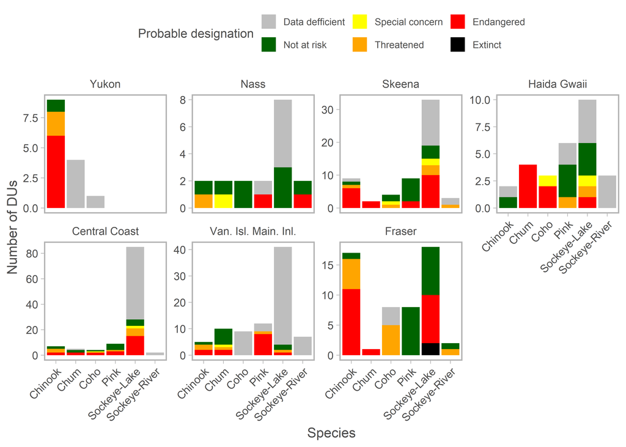

**Figure 1**. Status of all DUs. For DUs that have been previously assessed by COSEWIC the official status is shown, otherwise probable status is inferred based on COSEWIC Criteria A2 (% change in mature individual abundance over the most recent three generations of data) and D1 (absolute abundance).

## 3.2 Unassessed DUs with data - plot

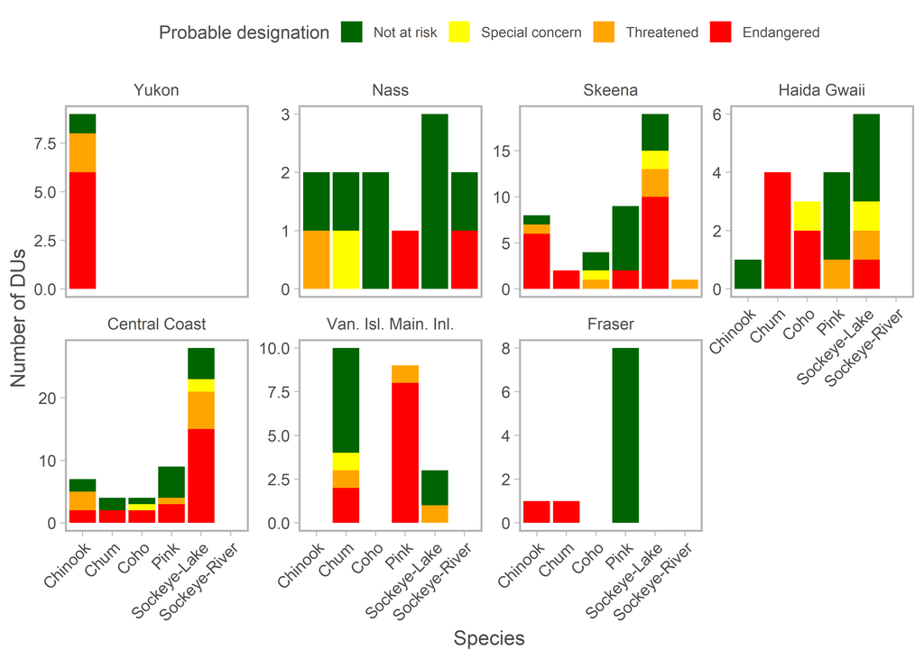

**Figure 2**. Probable status of unassessed Pacific salmon DUs based on COSEWIC Criteria A2 (% change in mature individual abundance over the most recent three generations of data) and D1 (absolute abundance).

## 3.3 All DUs - table

| Region | DU name | DU no. | Species | Generation length | COSEWIC status | % Change (recent) | % Change (all) | Recent abundance | Last year | Probable status | Status |
| --- | --- | --- | --- | --- | --- | --- | --- | --- | --- | --- | --- |
| Fraser | Boundary Bay-Ocean-Fall | CK1 | Chinook | 5 | Threatened | 457 | 32 | 103 | 2018 | Endangered | Threatened |
| Fraser | Middle Fraser-Stream-Summer | CK10 | Chinook | 5 | Threatened | -35 | -5 | 13268 | 2023 | Threatened | Threatened |
| Fraser | Upper Fraser-Stream-Spring | CK11 | Chinook | 5 | Endangered | -34 | -12 | 11459 | 2023 | Threatened | Endangered |
| Fraser | South Thompson-Ocean-Summer | CK12 | Chinook | 4 | Not at risk | 278 | 96 | 641132 | 2023 | Not at risk | Not at risk |
| Fraser | South Thompson-Stream-Summer | CK13 | Chinook | 5 | Endangered | 41 | 5 | 1180 | 2023 | Not at risk | Endangered |
| Fraser | South Thompson-Stream-Summer | CK14 | Chinook | 4 | Endangered | -82 | -18 | 17 | 2023 | Endangered | Endangered |
| Fraser | Lower Thompson-Stream-Spring | CK15 | Chinook | 4 | Endangered | -33 | 7 | 11008 | 2023 | Threatened | Endangered |
| Fraser | North Thompson-Stream-Spring | CK16 | Chinook | 5 | Endangered | 113 | -42 | 454 | 2023 | Threatened | Endangered |
| Fraser | North Thompson-Stream-Summer | CK17 | Chinook | 5 | Endangered | 41 | -11 | 4593 | 2023 | Not at risk | Endangered |
| Van. Isl. Main. Inl. | Georgia Strait-Ocean-Fall | CK18 | Chinook | 4 | Data Deficient | 90 | 2 | 1337 | 2018 | Not at risk | Data Deficient |

[output cut: 375 more lines]

# 4 Abundance plots

Plots of reconstructed number of mature individuals (spawners) over time for each DU, by region and species. Show are raw estimates with trend (estimated in log[e] space) over the most recent three generations (red line) or entire time-series (black dashed line).

## 4.1 Yukon

### 4.1.1 Chinook

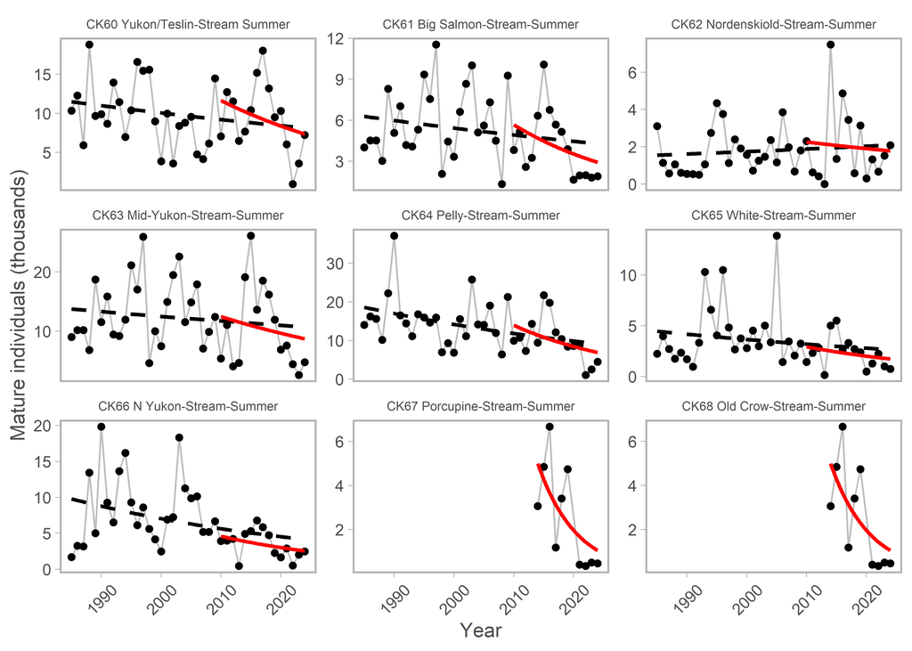

## 4.2 Nass

### 4.2.1 Chinook

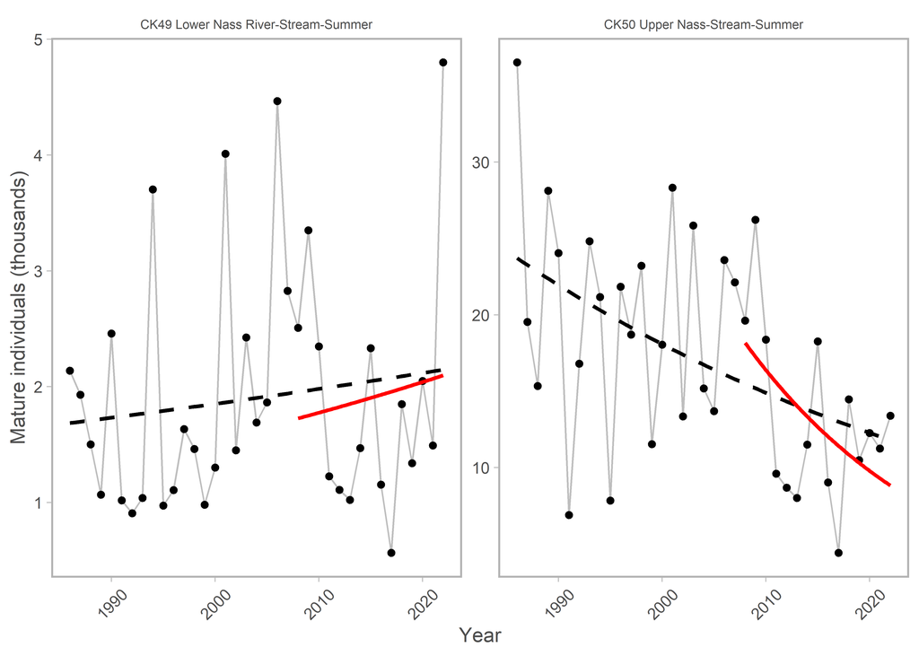

### 4.2.2 Chum

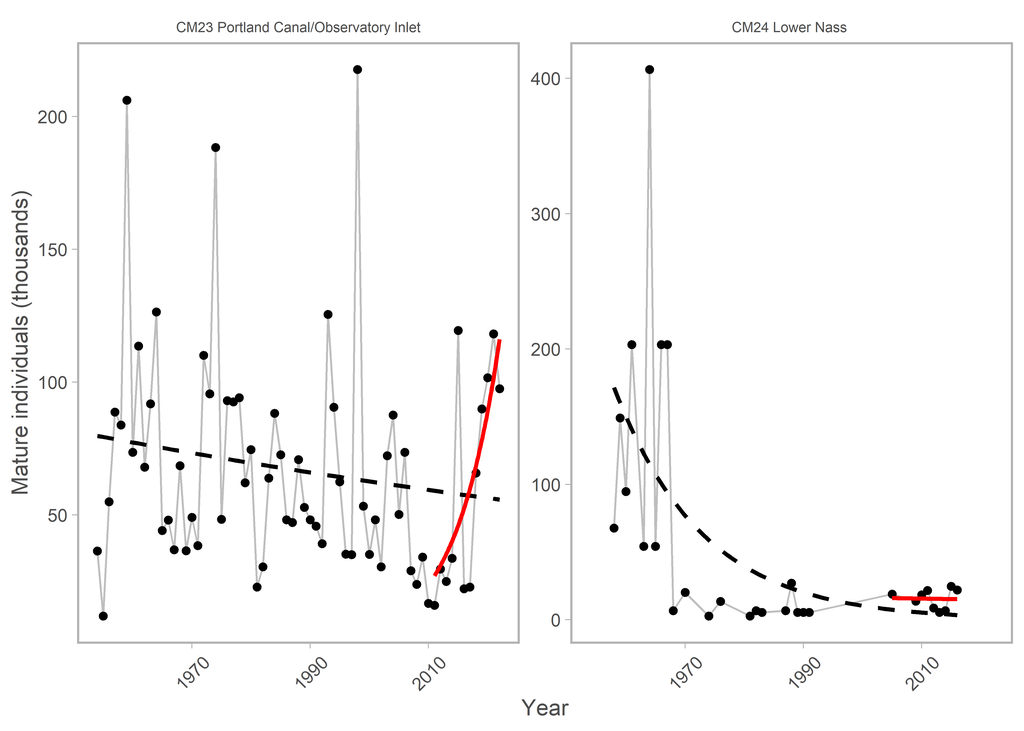

### 4.2.3 Coho

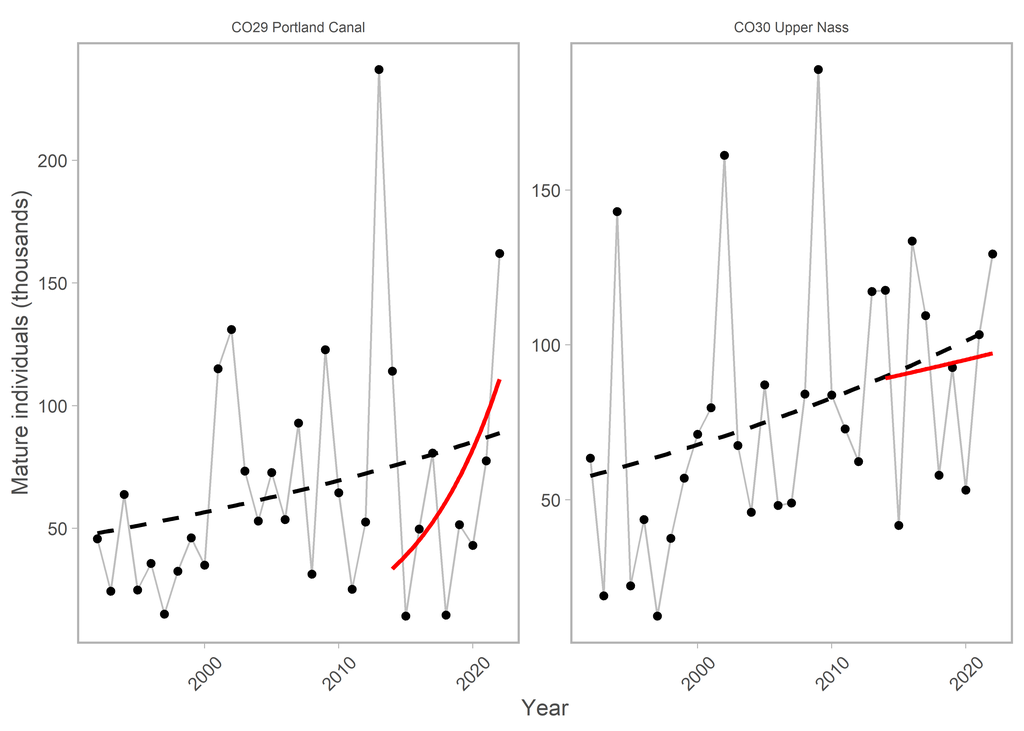

### 4.2.4 Pink (odd)

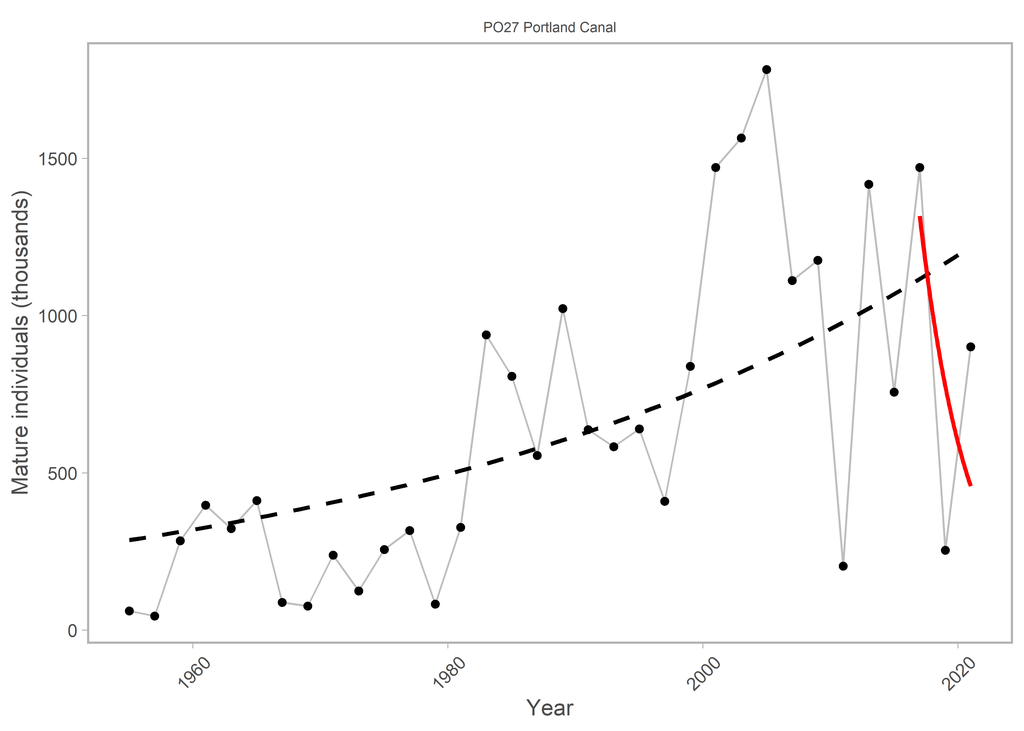

### 4.2.5 River sockeye

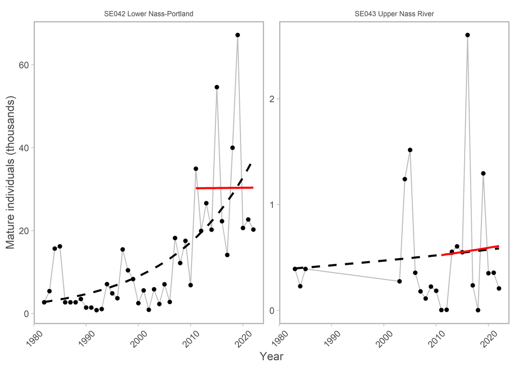

### 4.2.6 Lake sockeye

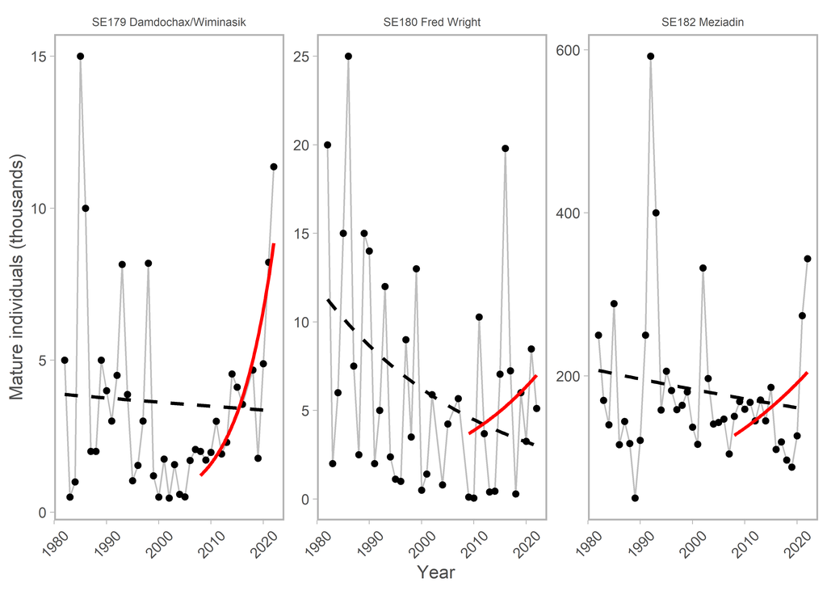

## 4.3 Skeena

### 4.3.1 Chinook

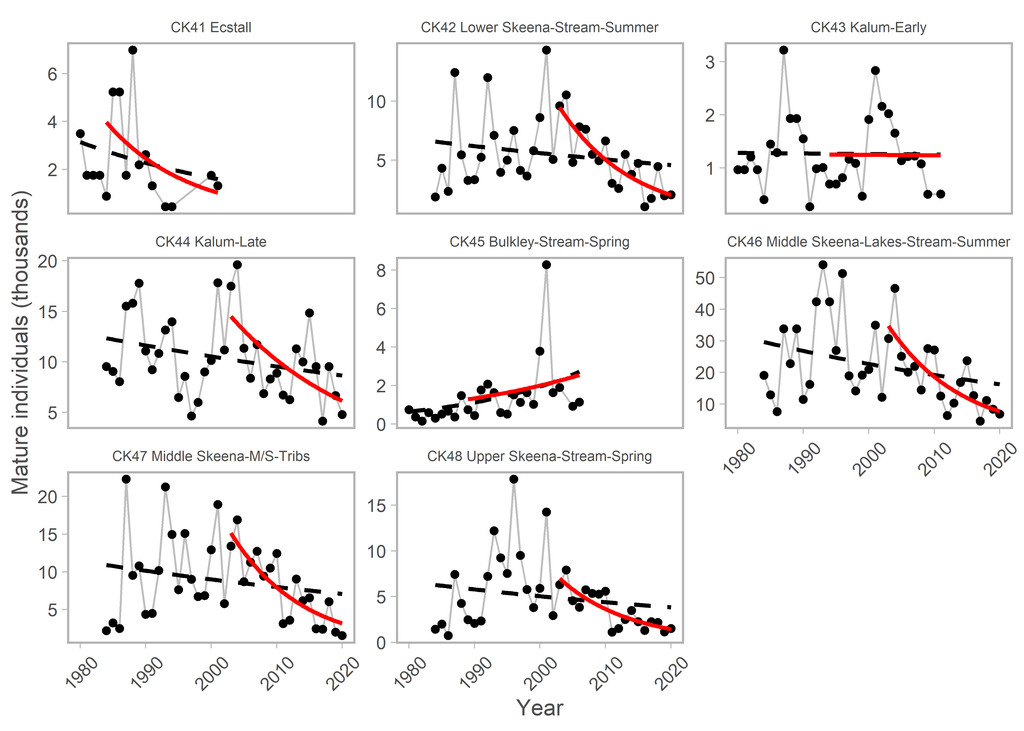

### 4.3.2 Chum

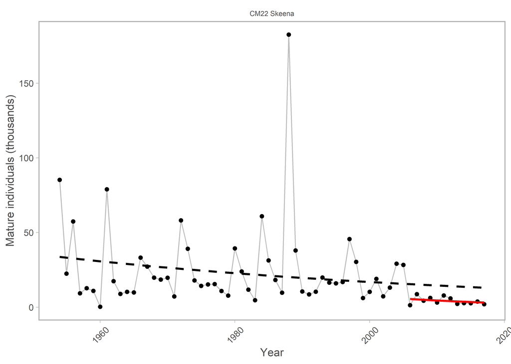

### 4.3.3 Coho

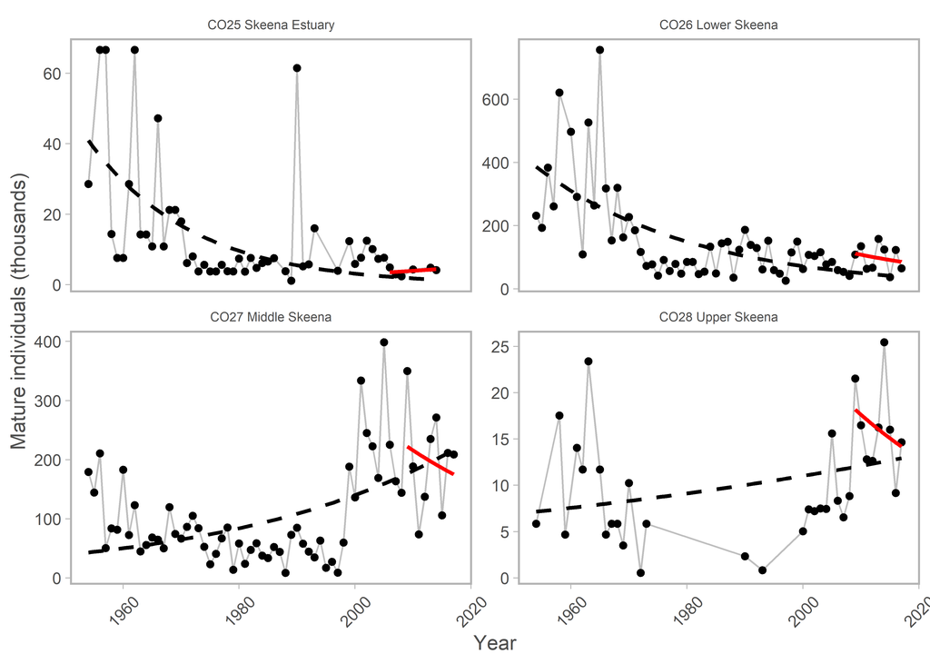

### 4.3.4 Pink (even)

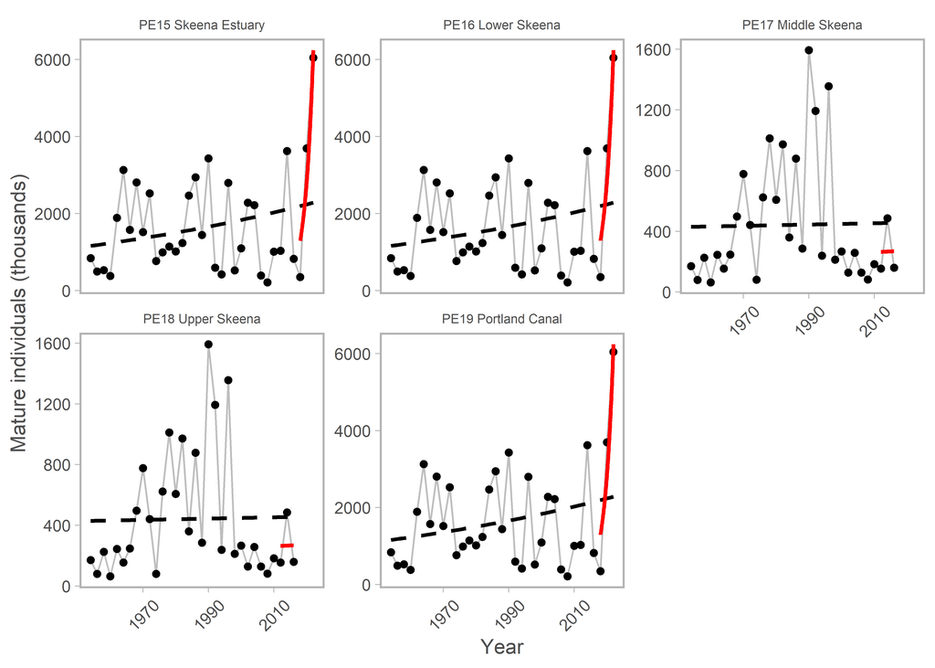

### 4.3.5 Pink (odd)

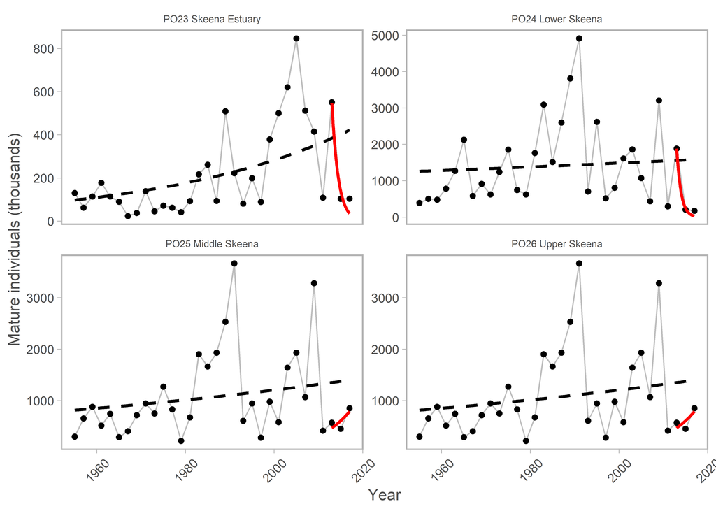

### 4.3.6 River sockeye

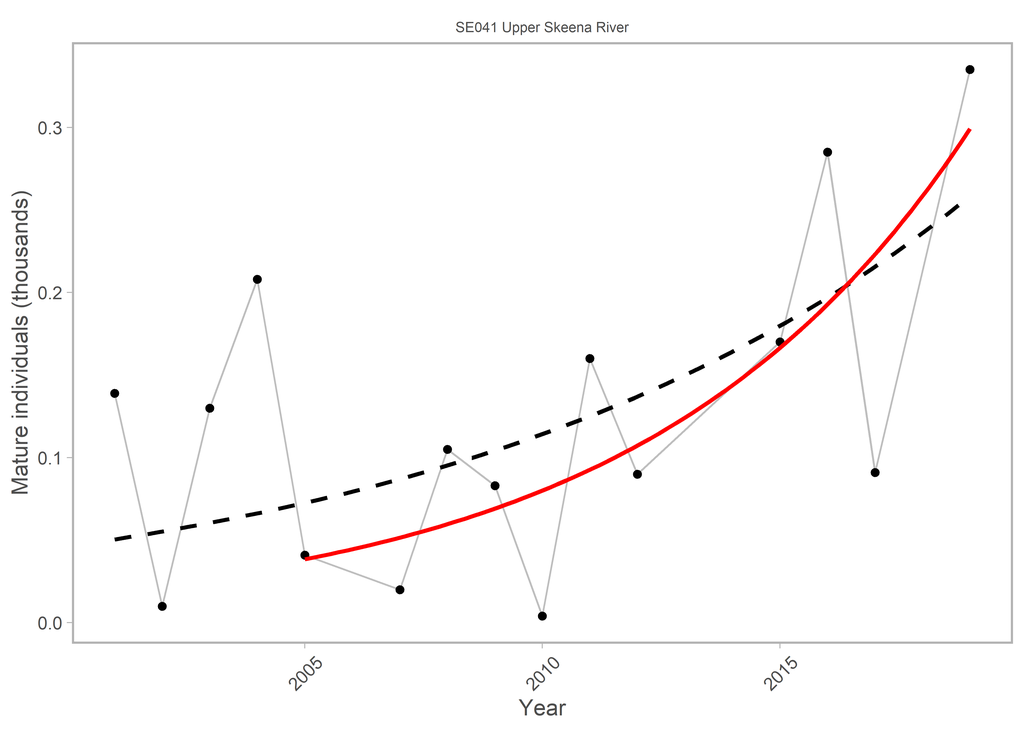

### 4.3.7 Lake sockeye

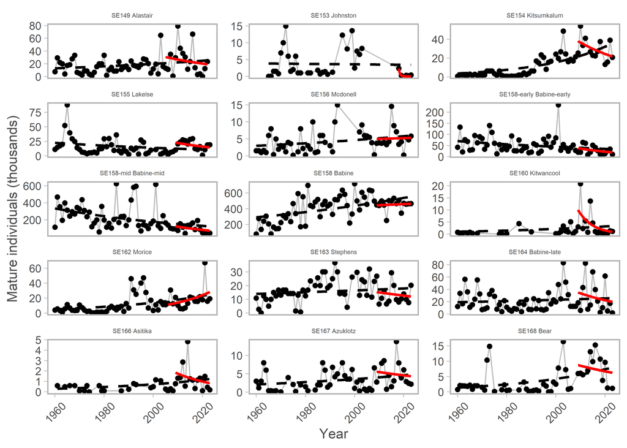

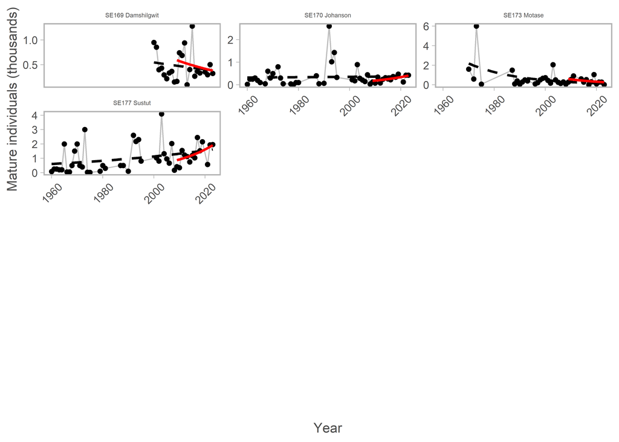

## 4.4 Haida Gwaii

### 4.4.1 Chinook

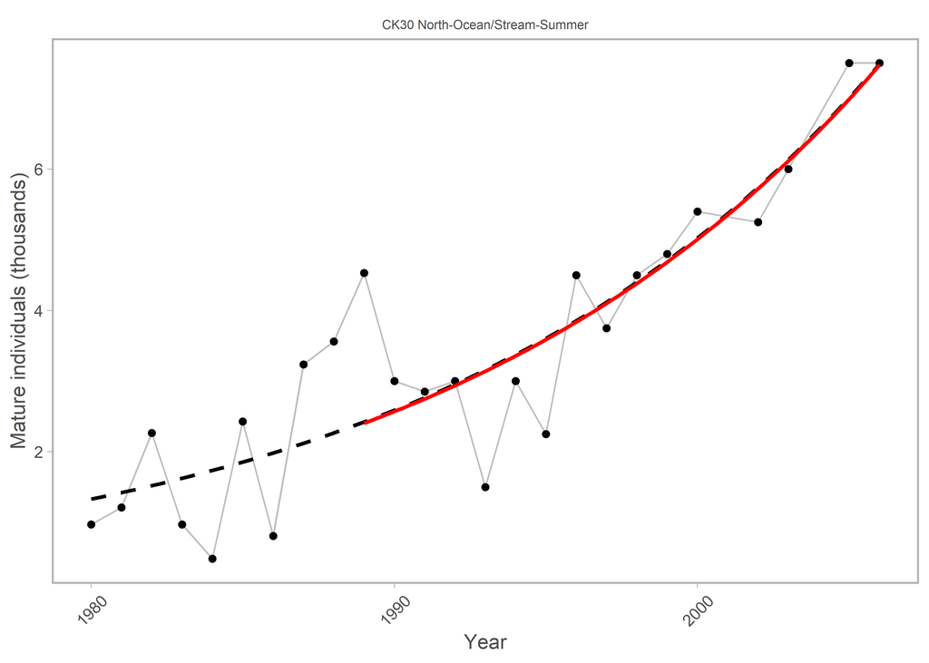

### 4.4.2 Chum

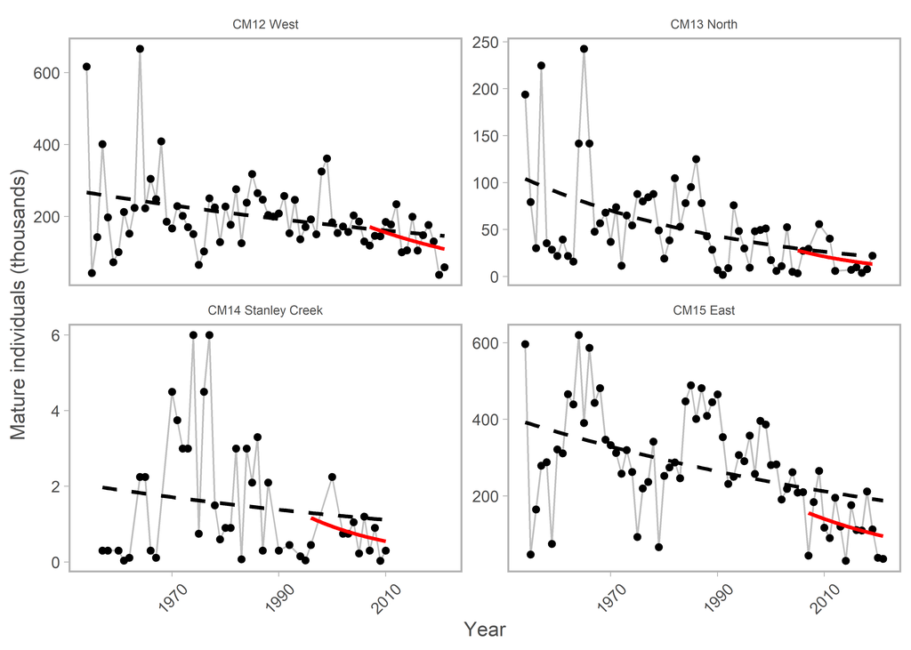

### 4.4.3 Coho

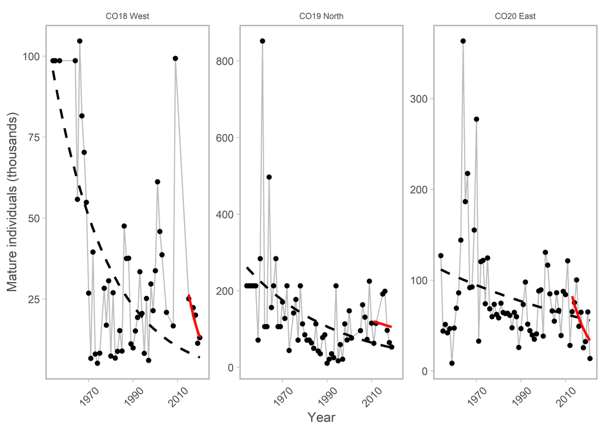

### 4.4.4 Pink (even)

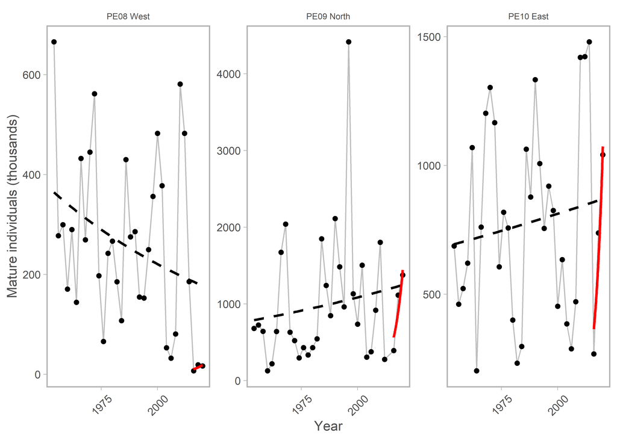

### 4.4.5 Pink (odd)

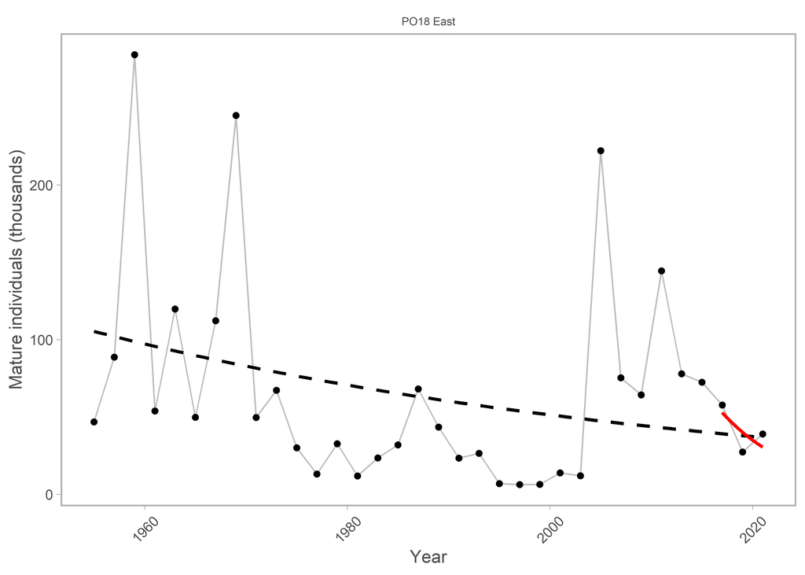

### 4.4.6 Lake sockeye

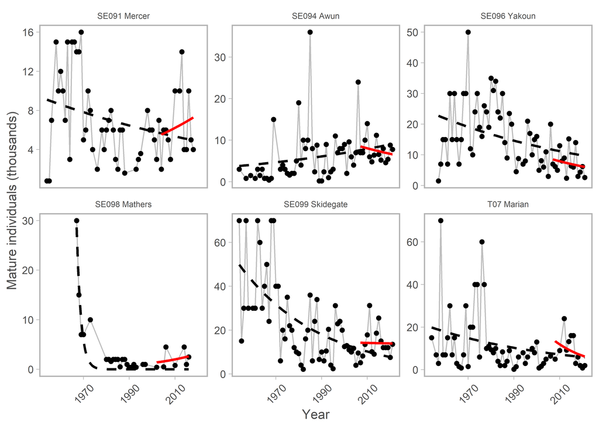

## 4.5 Central Coast

### 4.5.1 Chinook

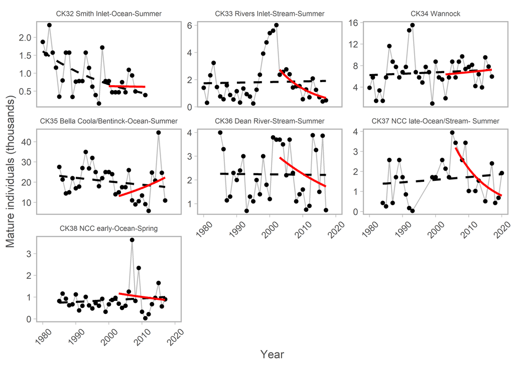

### 4.5.2 Chum

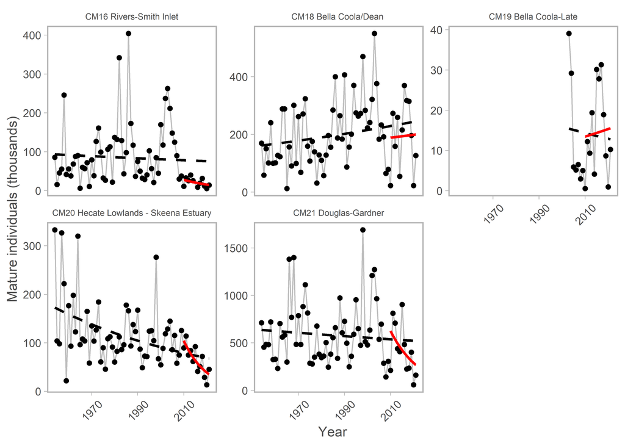

### 4.5.3 Coho

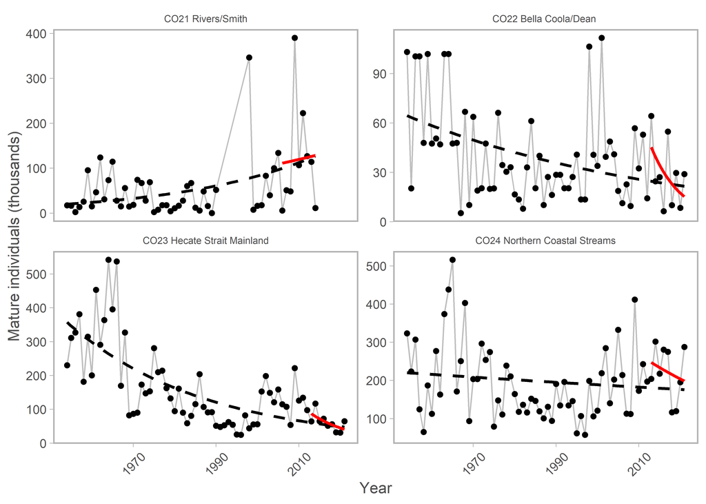

### 4.5.4 Pink (even)

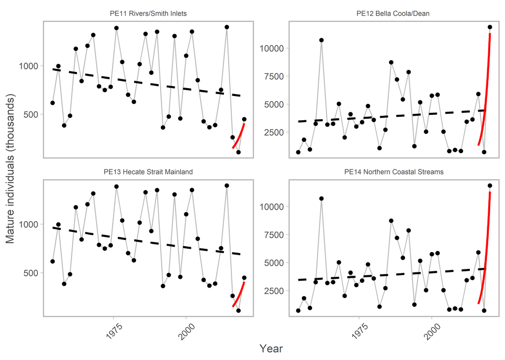

### 4.5.5 Pink (odd)

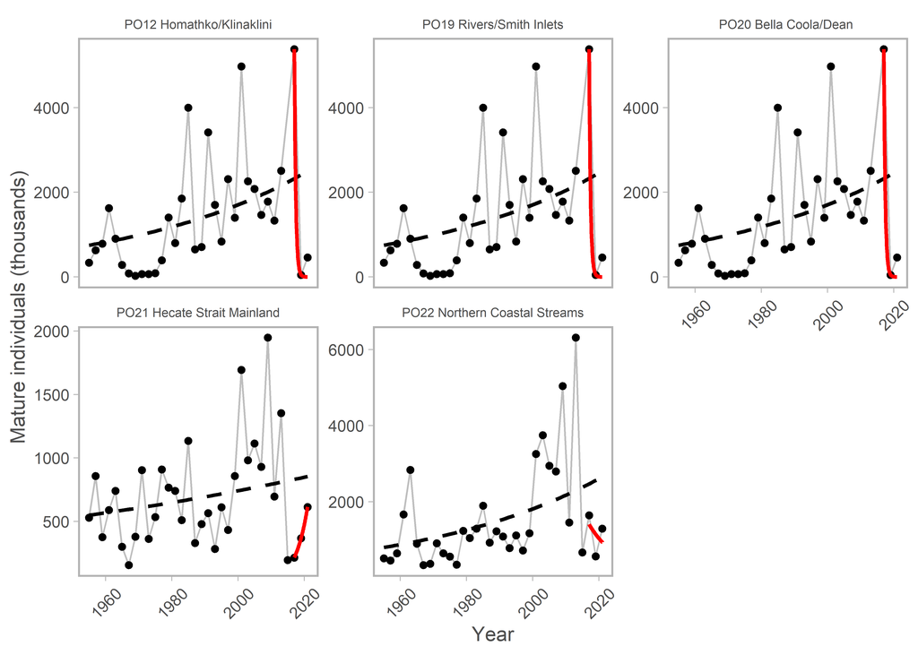

### 4.5.6 River sockeye

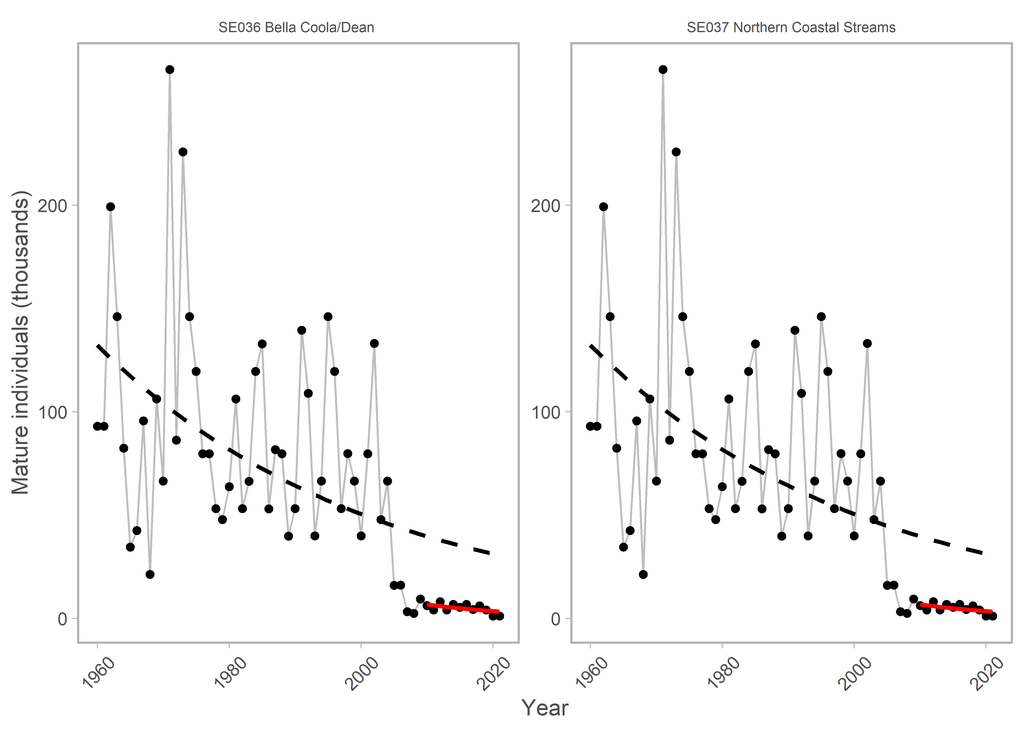

### 4.5.7 Lake sockeye

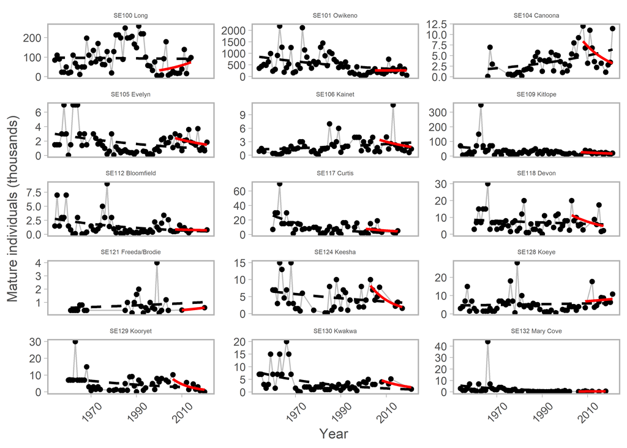

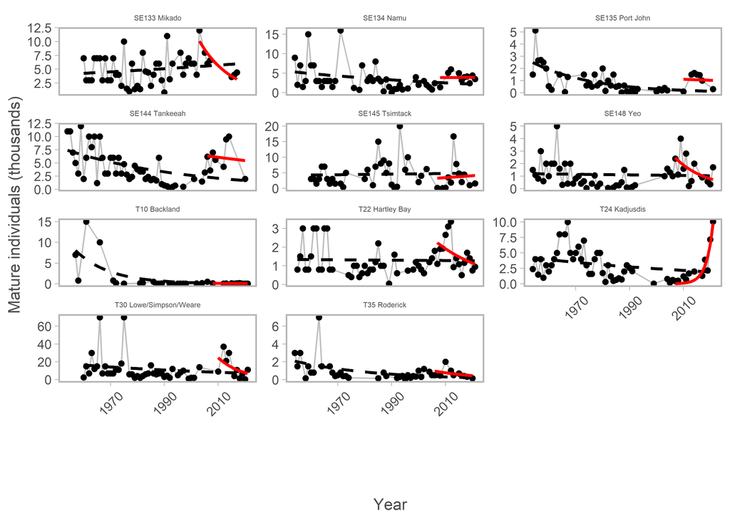